# Analsis of Imputed Data

William Murrah

## Packages we will use:

```r
require(texreg)
require(mice)
require(VIM)
require(ztable)
require(lattice)
require(mice)
require(psych)
require(miceadds)
source("~/Rfunc/miralm.R")
```

```r
doctype <-
   # "latex"
   "html"
txreg <- ifelse(doctype == "latex", texreg, htmlreg)
options(ztable.type = doctype)
```

## Data example

NHANES

```r
headTail(nhanes, tlength = 10) # from `psych` package
```

```
    age  bmi  hyp  chl
1     1 <NA> <NA> <NA>
2     2 22.7    1  187
3     1 <NA>    1  187
4     3 <NA> <NA> <NA>
... ...  ...  ...  ...
16    1 <NA> <NA> <NA>
17    3 27.2    2  284
18    2 26.3    2  199
19    1 35.3    1  218
20    3 25.5    2 <NA>
21    1 <NA> <NA> <NA>
22    1 33.2    1  229
23    1 27.5    1  131
24    3 24.9    1 <NA>
25    2 27.4    1  186
```

```r
md.pattern(nhanes)
```

```
   age hyp bmi chl
13   1   1   1   1  0
 1   1   1   0   1  1
 3   1   1   1   0  1
 1   1   0   0   1  2
 7   1   0   0   0  3
     0   8   9  10 27
```

```r
lmfit <- lm(chl~bmi+age,data=nhanes)
```

```r
htmlreg(lmfit, custom.model.names = "listwise")
```

Statistical models

|  | **listwise** |
| --- | --- |
| (Intercept) | -80.19 |
|  | (58.77) |
| bmi | 6.88** |
|  | (1.85) |
| age | 53.07*** |
|  | (11.29) |
| R<sup>2</sup> | 0.73 |
| Adj. R<sup>2</sup> | 0.68 |
| Num. obs. | 13 |
| RMSE | 27.67 |
| p < 0.001, p < 0.01, p < 0.05 |  |

```r
imp <- mice(data = nhanes, m = 5, maxit = 20, seed = 20151110,
            printFlag = FALSE)
```

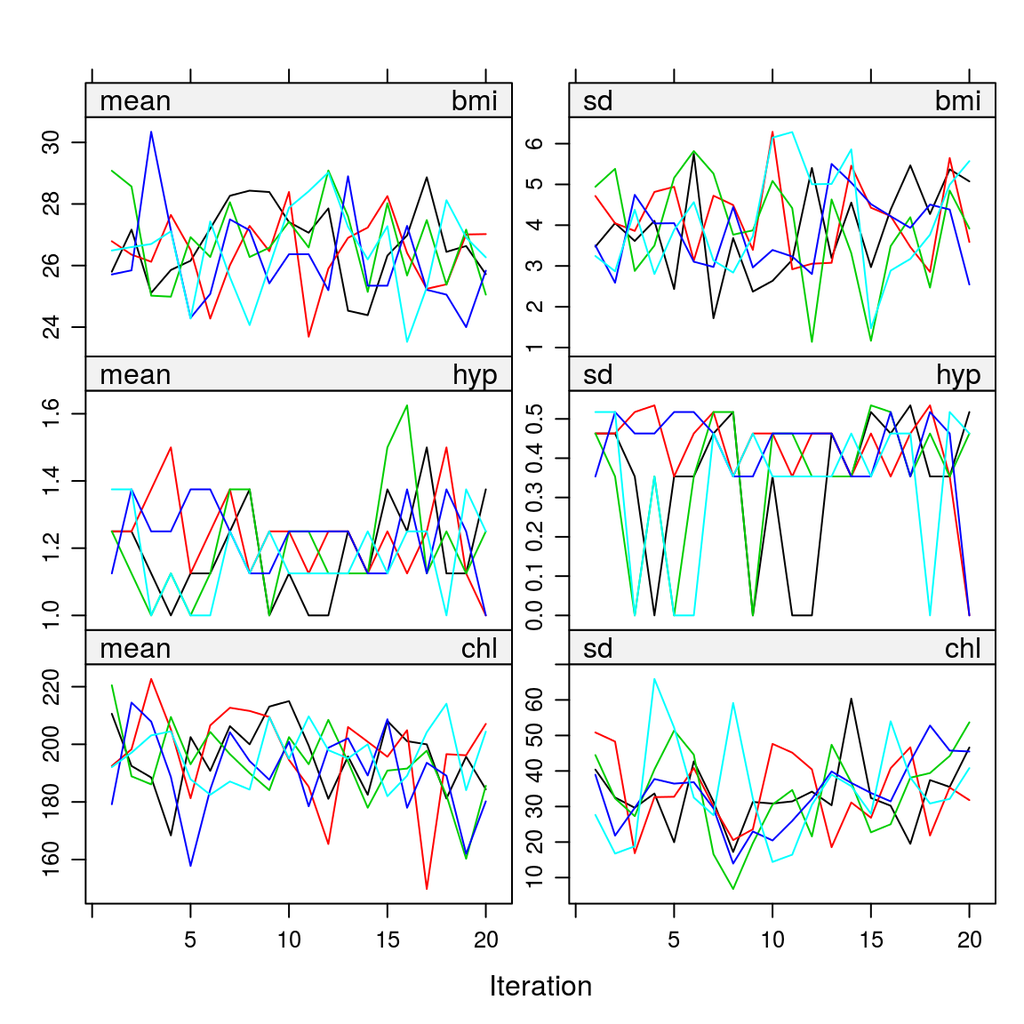

```r
plot(imp)
```

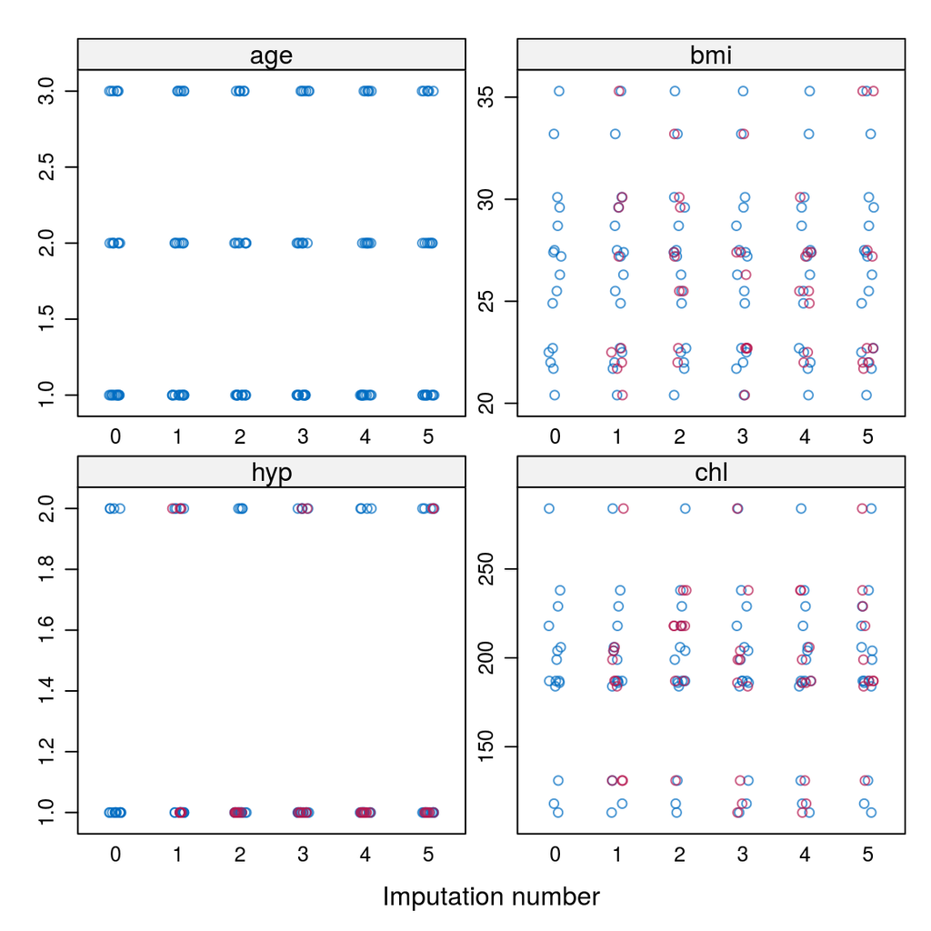

```r
stripplot(imp)
```

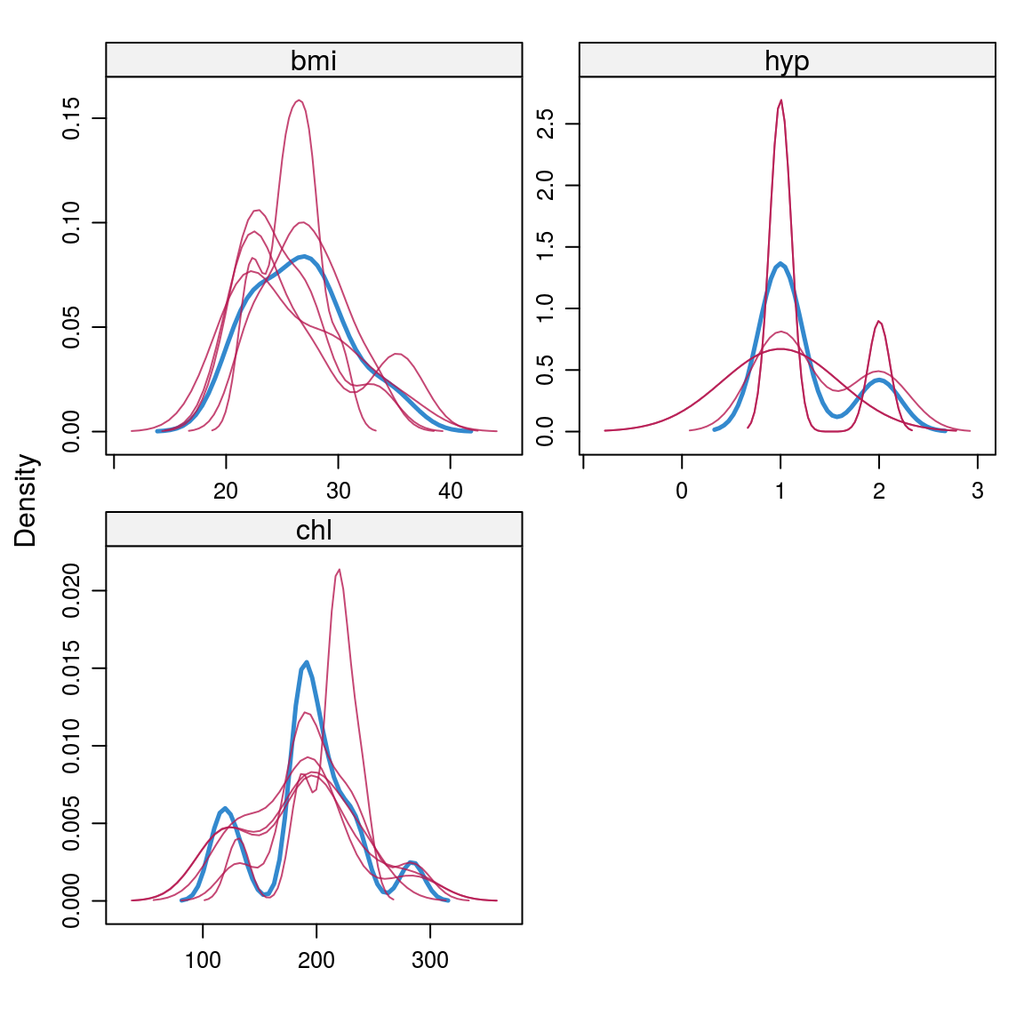

```r
densityplot(imp)
```

## What **NOT** to do with imputed data

1. Average data sets
2. Stack data sets

```r
stacked <- complete(imp, "long")
stackfit <- lm(chl~bmi+age,data=stacked)
htmlreg(list(lmfit, stackfit), custom.model.names = c("listwise", "stacked"))
```

Statistical models

|  | **listwise** | **stacked** |
| --- | --- | --- |
| (Intercept) | -80.19 | -17.68 |
|  | (58.77) | (23.81) |
| bmi | 6.88** | 5.70*** |
|  | (1.85) | (0.77) |
| age | 53.07*** | 33.62*** |
|  | (11.29) | (3.88) |
| R<sup>2</sup> | 0.73 | 0.44 |
| Adj. R<sup>2</sup> | 0.68 | 0.43 |
| Num. obs. | 13 | 125 |
| RMSE | 27.67 | 32.98 |
| p < 0.001, p < 0.01, p < 0.05 |  |  |

## Repeated Analyses: What you **SHOULD** do

The appropriate way to analyze MI data is to do repeated analyses and pool parameter estimates.

The following block quote is from Molenberghs et al. (2014).

Multiple imputation is a procedure that enables the user to carry on with their standard analysis almost as if the dataset contained no missing values. The method proceeds as follows:

> 1. Create a number ($m$) of copies of the incomplete dataset, and use an appropriate procedure to impute (fill in) the missing values in each of these copies. Since we do not know the true values that are missing it seems reasonable that the imputed values used in each copy should in general be different from each other.
> 2. For each completed (imputed) copy of the dataset, carry out the standard analysis that would have been performed in the absence of missing values, and store the parameter estimates of interest, along with their estimated standard errors (or variance/covariance matrix in the case of a multivariate parameter of interest). Here … the focus will be on a single (univariate) parameter of interest, which we denote $\beta$. The estimate of $\beta$ obtained from the $k^{th}(k = 1, . . .,m)$ completed dataset is denoted $\beta^{(k)}$ and its (estimated) variance $V^{(k)}$. (Note that this step implicitly assumes that the inference desired from the analysis can be effectively reduced to a parameter estimate and standard error.)
> 3. Use a pair of formulas widely known as “Rubin’s rules,”" firstly to create a combined estimate of the parameter, as the average of the $m$ separate estimates:

$\hat{\beta}^{MI} = \frac{1}{m} \sum_1^m \hat{\beta}^{(K)},$

> and then to obtain a standard error for this estimate, as the square root of the following combined variance estimate:

$V^{(MI)} = \bar{V} + \left(1 + \frac{1}{m} \right)B,$

> where $\bar{V} = \sum_1^m V^{(k)}/m$, and $B = \sum_1^m (\hat{\beta}^{k} - \hat{\beta}^{MI})^2/(m - 1)$, which is an estimate of the *between-imputation* variance of the parameter of interest. In general multiple-imputation inference proceeds in the usual way from these results, by forming test statistics and confidence intervals under the assumption that $(\hat{\beta}^{MI} - \beta)/\sqrt{V^{MI}}$ follows either a standard normal or $t$ distribution.

### Repeated Analyses:

```r
fit <- with(imp, lm(chl ~ bmi + age))
# Grab estimates from first analysis:
coef(fit$analyses[[1]])
```

```
(Intercept)         bmi         age
 -70.724270    7.249243   39.181337
```

```r
# Grab estimates from second analysis:
coef(fit$analyses[[2]])
```

```
(Intercept)         bmi         age
  -4.029935    5.609304   29.422987
```

### Pool estimates:

```r
est <- pool(fit)
summary(est)
```

```
                   est        se          t        df   Pr(>|t|)
(Intercept) -14.447919 71.228352 -0.2028394  8.750461 0.84389830
bmi           5.576861  2.276417  2.4498420  9.440161 0.03559572
age          33.667583 10.804393  3.1161014 10.465967 0.01038711
                   lo 95     hi 95 nmis       fmi    lambda
(Intercept) -176.2808101 147.38497   NA 0.4815692 0.3752294
bmi            0.4636184  10.69010    9 0.4524648 0.3475746
age            9.7383906  57.59678    0 0.4122115 0.3096840
```

### Using other functions on imputed data:

```r
expr <- expression(mean.bmi <- mean(bmi))
out <- with(imp, eval(expr))
unlist(out$analyses)
```

```
[1] 26.260 26.728 26.020 26.300 26.456
```

```r
mean(unlist(out$analyses))
```

```
[1] 26.3528
```

```r
mids2mplus(imp, path = "data/mplusData/")
```

```r
mids2spss(imp, path = "data/spssData/")
```

```r
source("~/FOCAL/Rpackages/cpar/R/miralm.R")
miralmObj <- miralm(mira = fit, n.obs = 25)
htmlreg(list(lmfit, stackfit, miralmObj), custom.model.names = c("listwise", "stacked", "mice"))
```

Statistical models

|  | **listwise** | **stacked** | **mice** |
| --- | --- | --- | --- |
| (Intercept) | -80.19 | -17.68 | -14.45 |
|  | (58.77) | (23.81) | (71.23) |
| bmi | 6.88** | 5.70*** | 5.58* |
|  | (1.85) | (0.77) | (2.28) |
| age | 53.07*** | 33.62*** | 33.67* |
|  | (11.29) | (3.88) | (10.80) |
| R<sup>2</sup> | 0.73 | 0.44 | 0.46 |
| Adj. R<sup>2</sup> | 0.68 | 0.43 | 0.41 |
| Num. obs. | 13 | 125 | 25 |
| RMSE | 27.67 | 32.98 |  |
| p < 0.001, p < 0.01, p < 0.05 |  |  |  |

References

Molenberghs, Geert, Garrett Fitzmaurice, Michael G Kenward, Anastasios Tsiatis, and Geert Verbeke. 2014. *Handbook of Missing Data Methodology*. CRC Press.